# Assignment 6: Singular Value Decomposition

Danny Godbout

August 8, 2016

### SVD Model

This SVD model predicts log-price on make, fuel-type, aspiration, body style, drive wheels, length, curb weight, engine type, cylinder count, engine size and city mpg. When factors are broken out into individual levels, the **dimensionality of the model increases from 12 to 46.**

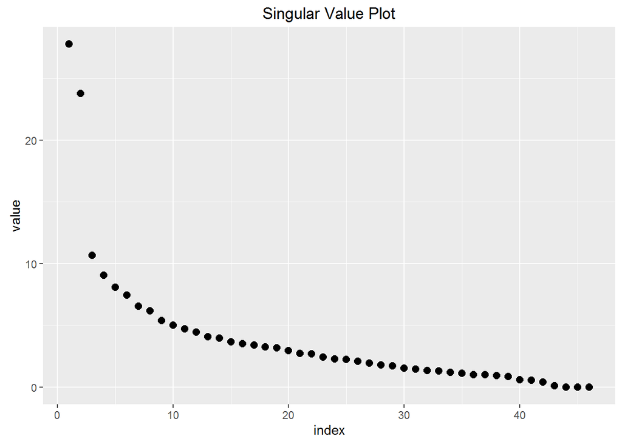

Generating the SVD modeling coefficients yields the following SV plot:

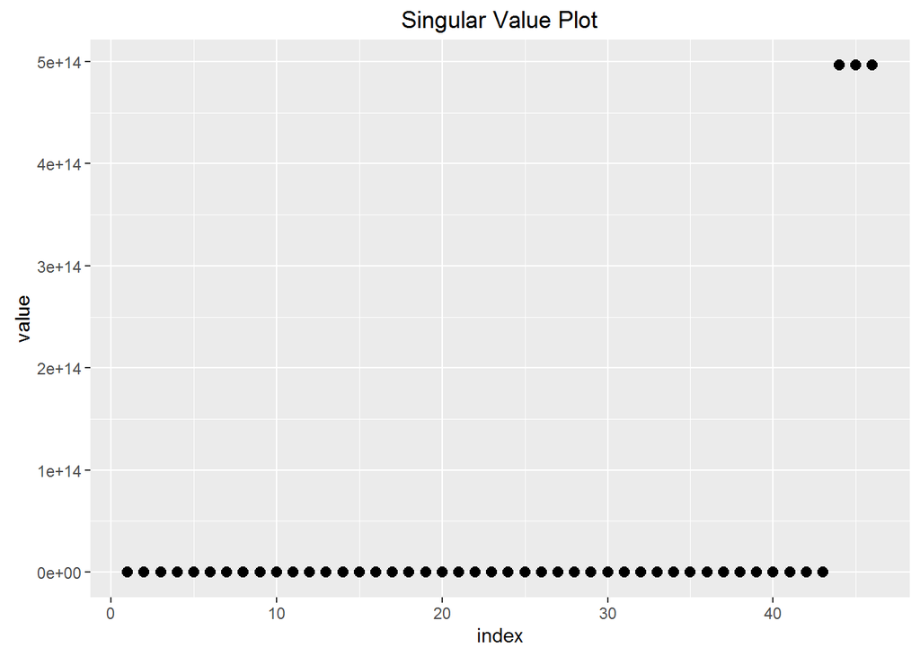

Re-calculating the modeling coefficients with the last 3 coefficients set to zero yields the following result. In the end, the **model will use 43 features.**

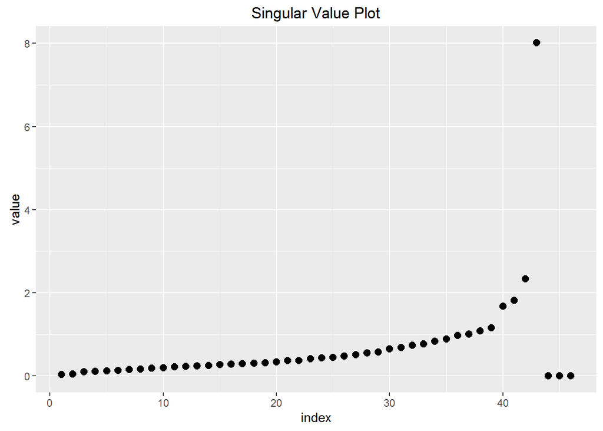

```
[1] "RMSE of model with 46 features:"
```

```
[1] 0.1312438
```

```
[1] "RMSE of model with 43 features:"
```

```
[1] 0.1029465
```

Diagnostic plot of full model:

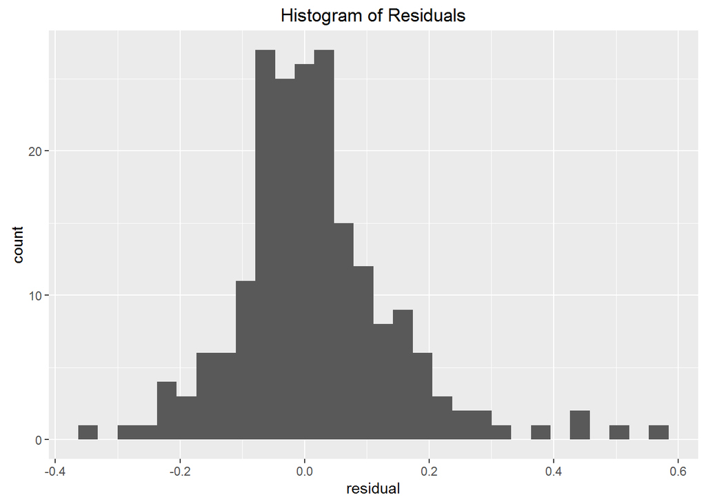

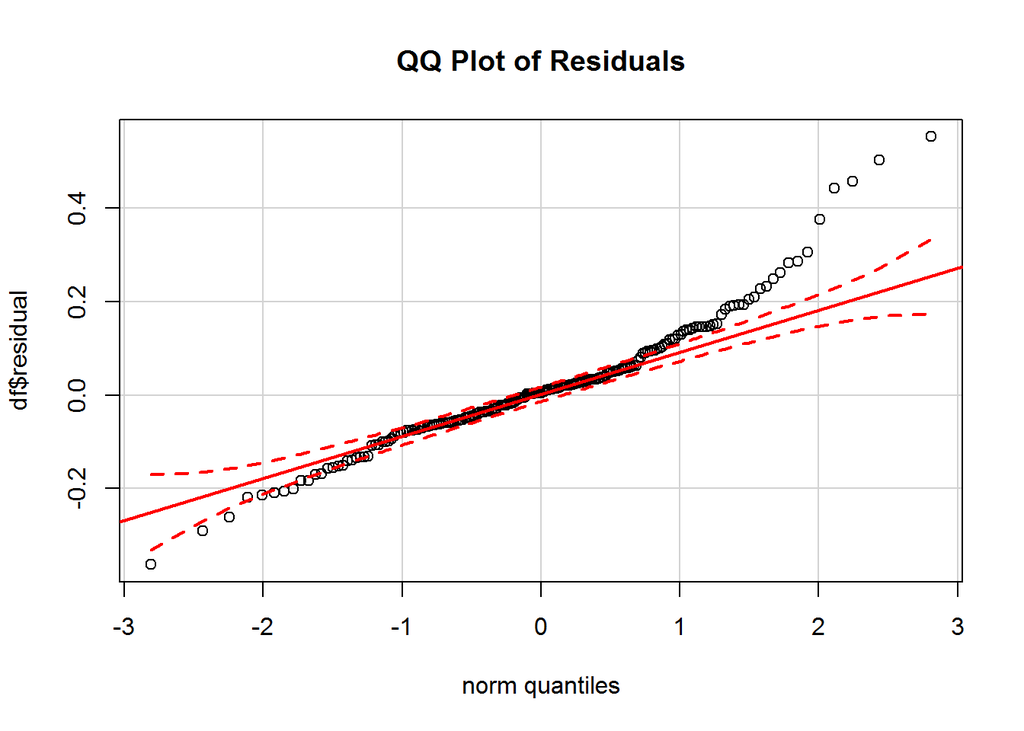

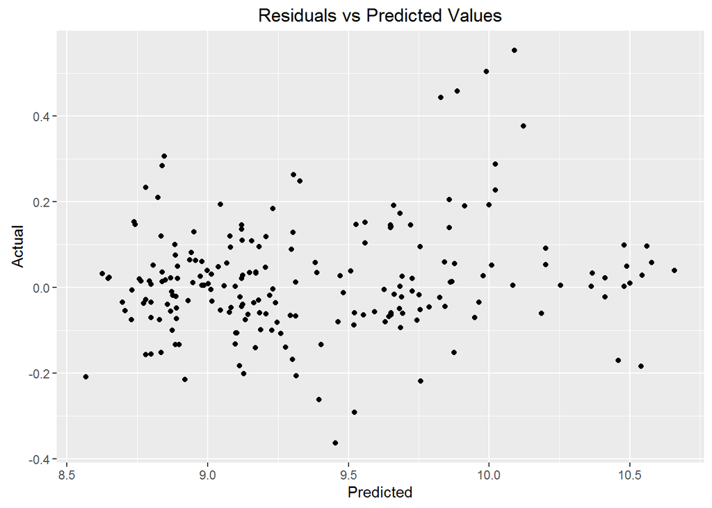

Diagnostic plots of model with 43 features:

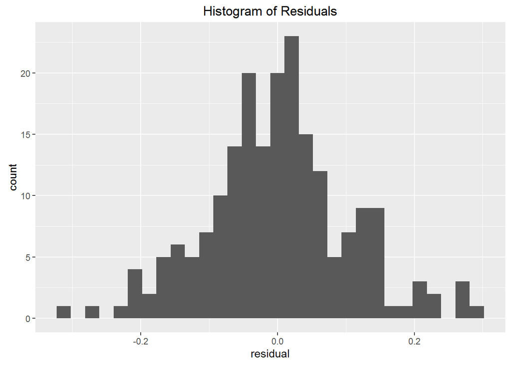

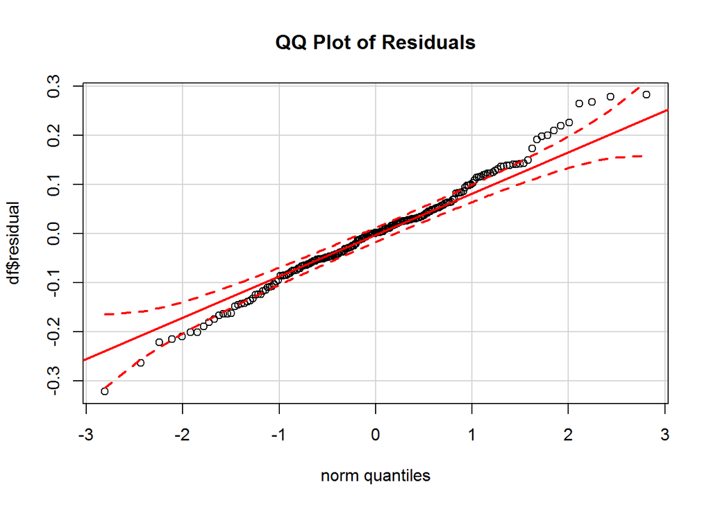

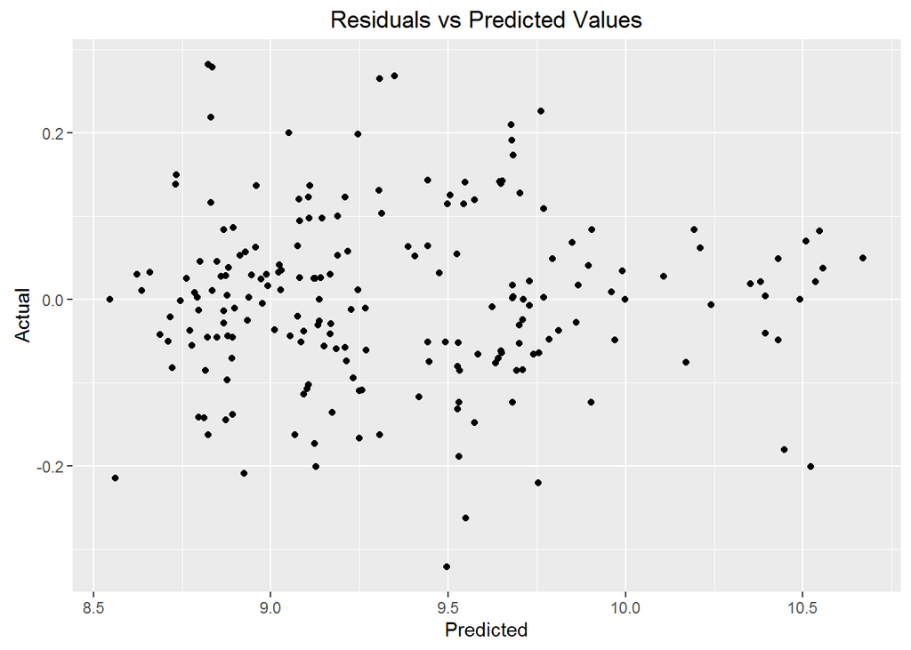

### Stepwise Regression

Performing a stepwise regression on the auto price data, and using the same model features as the SVD, we see that the stepwise algorithm similarly drops features to optimize the model. Specifically, the stepwise regression drops fuel type, length, and number of cylinders:

```
Stepwise Model Path
Analysis of Deviance Table

Initial Model:
log.price ~ 0 + (make + fuel.type + aspiration + body.style +
    drive.wheels + length + curb.weight + engine.type + num.of.cylinders +
    engine.size + city.mpg)

Final Model:
log.price ~ make + aspiration + body.style + drive.wheels + curb.weight +
    engine.type + engine.size + city.mpg - 1

                Step Df     Deviance Resid. Df Resid. Dev       AIC
1                                          158   2.130196 -827.9653
2 - num.of.cylinders  4 0.0541036198       162   2.184299 -830.9240
3        - fuel.type  1 0.0004022263       163   2.184702 -832.8870
4           - length  1 0.0209663322       164   2.205668 -832.9672
```

Comparing the RMSE of the stepwise regression to the optimal SVD model (RMSE = 0.1029465), we see a similar result:

```
[1] "RMSE:"
```

```
[1] 0.1159707
```

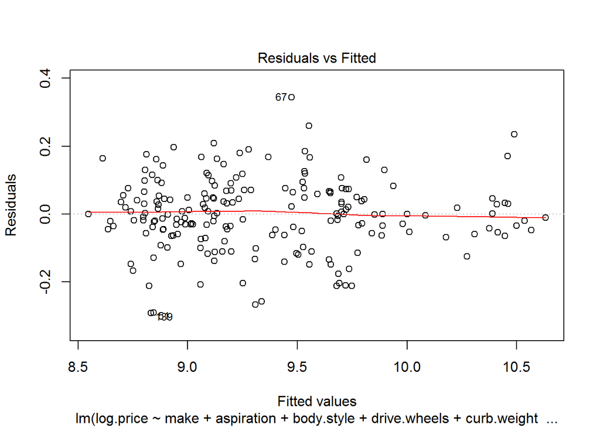

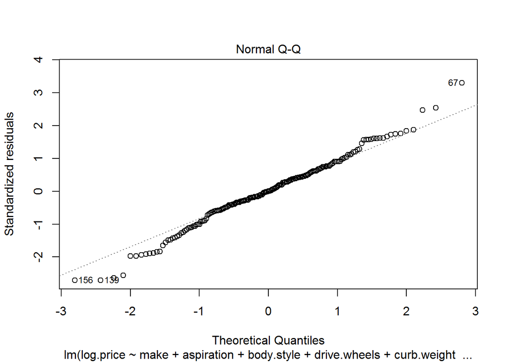

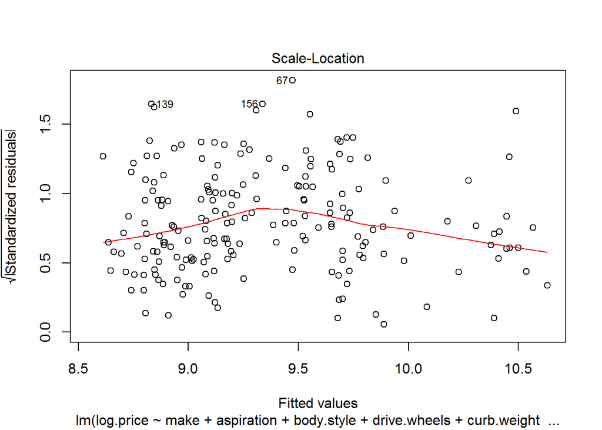

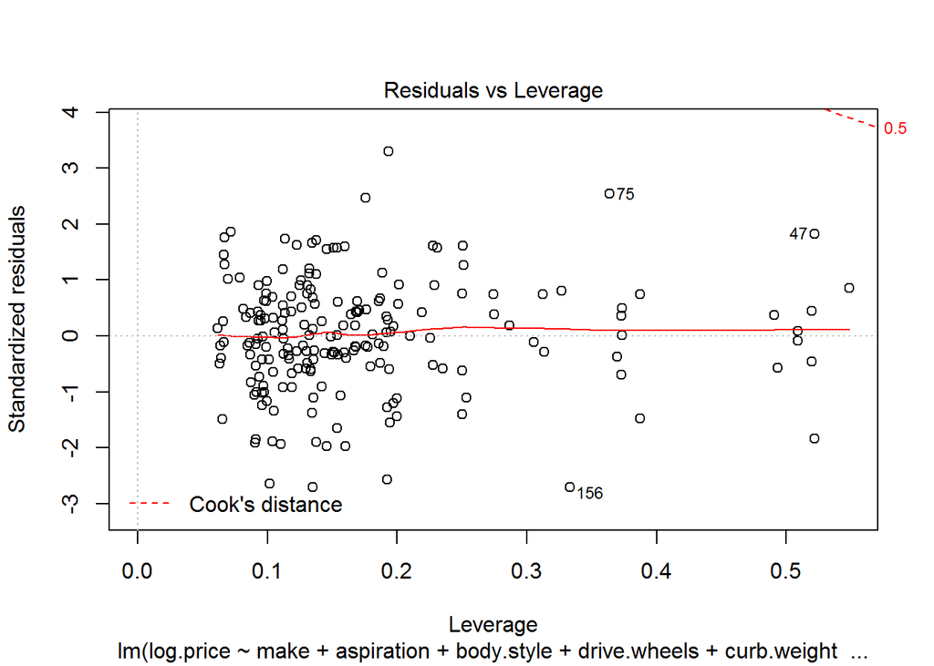

### Source Code

```r
library(dplyr)
library(ggplot2)
library(car)
library(MASS)


#~~~~~~~~~~~~~~~~~~~~~~~~~~~~~~~~~~~~~~~~~~~~~~~~~~~~~~~~~~
####  Import and set typing + basic calculated columns ####
#~~~~~~~~~~~~~~~~~~~~~~~~~~~~~~~~~~~~~~~~~~~~~~~~~~~~~~~~~~

# Import
auto.data <- read.csv('Automobile price data _Raw_.csv', stringsAsFactors = FALSE)

# Set types on factor columns
factor.cols <- c("make", "fuel.type", "aspiration", "num.of.doors",
                 "body.style", "drive.wheels", "engine.location",
                 "engine.type", "num.of.cylinders", "fuel.system")
auto.data[, factor.cols] <- lapply(auto.data[factor.cols], as.factor)

# Set types on numeric columns
numeric.cols <- c("wheel.base", "length", "width", "height",
                  "curb.weight", "engine.size", "bore", "stroke",
                  "compression.ratio", "horsepower", "peak.rpm",
                  "city.mpg", "highway.mpg", "price")
auto.data[, numeric.cols] <- lapply(auto.data[numeric.cols], as.numeric)

# Calculate log-price column
auto.data <- auto.data %>% mutate(log.price = log(price))





#~~~~~~~~~~~~~~~~~~~~~~~~~~~~
####  Set model features ####
#~~~~~~~~~~~~~~~~~~~~~~~~~~~~

## Select modeling columns
model.features <- c("make", "fuel.type", "aspiration", "body.style",
                    "drive.wheels", "length", "curb.weight", "engine.type",
                    "num.of.cylinders", "engine.size", "city.mpg", "log.price")

model.data <- auto.data[, model.features]


## Remove NAs
model.data <- na.exclude(model.data)


## Standardize numeric columns
numeric.features <- c("length", "curb.weight", "engine.size", "city.mpg")

model.data[, numeric.features] <- scale(model.data[, numeric.features])


#~~~~~~~~~~~~~~~~~~~~
#### Perform SVD ####
#~~~~~~~~~~~~~~~~~~~~

## Set formula to predict log price on all features. Remove intercept with 0:
model.formula <- log.price ~ 0 + .


## Build the model matrix from formula
auto.model.matrix <- model.matrix(model.formula, data = model.data)

## Perform SVD on model matrix
auto.svd <- svd(auto.model.matrix)

## Save the d-matrix
d <- diag(auto.svd$d)

## Plot singular values
f_singular_value_plot <- function(values) {
  ## Plots singular values of a matrix diagonal.
  ## Args:
  ##  values- matrix of values

  # Get list of diagonal values and format for plotting
  val_list <- data.frame("value" = diag(values), "index" = 1:length(diag(values)))

  # Build plot
  sv_plot <- ggplot(val_list, aes(index, value)) +
    geom_point(size = 2.5) +
    ggtitle("Singular Value Plot")
  print(sv_plot)

}
f_singular_value_plot(d)



## Calulate model coefficients
f_svd_coefficients <- function(df, svd, remove.features = NULL) {
  ## Function computes the SVD model coefficients
  ## Args:
  ##  df- data set to model on
  ##  svd- an svd object
  ##  remove.features- list of features to remove

  ## Compute the inverse the singular values
  dInv = diag(1/svd$d)
  print(dInv)

  ## If features have been chosen for removal, set to 0
  if(!is.null(remove.features)) {
    dInv[remove.features, remove.features] = 0.0
    print(dInv)
  }

  f_singular_value_plot(dInv)

  ## Compute the pseudo inverse
  pInv = svd$v %*% t(dInv) %*% t(svd$u)

  ## Compute the model coeficients
  b = pInv %*% as.matrix(df$log.price)

  return(b)
}
b <- f_svd_coefficients(model.data, auto.svd)

## Re-calculate model coefficients, with features 44-46 removed
b.elim <- f_svd_coefficients(model.data, auto.svd, remove.features = c(44, 45, 46))







## Evaluate model performance with and without dropped features
f_svd_predict <- function(df, df.matrix, model) {
  # Prediction
  df$pred <- as.matrix(df.matrix) %*% model

  # Residuals
  df$residual <- df$pred - df$log.price

  # Square of residuals
  df$sq.res <- df$residual ^ 2

  return(df)
}

b.prediction <- f_svd_predict(model.data, auto.model.matrix, b)
b.elim.prediction <- f_svd_predict(model.data, auto.model.matrix, b.elim)

## RMSE
f_rmse <- function(sq.residuals) {
  rmse <- sqrt(mean(sq.residuals))
  return(rmse)
}

rmse.b <- f_rmse(b.prediction$sq.res)
rmse.b
rmse.b.elim <- f_rmse(b.elim.prediction$sq.res)
rmse.b.elim

## Print diagnostic plots
plot.diagnostic = function(df){

    ## Histogram of residuals
  hist_residuals <- ggplot(df, aes(residual)) +
    geom_histogram(bins = 30) +
    ggtitle("Histogram of Residuals")
  print(hist_residuals)

  ## QQ Plot
  qqPlot(df$residual, main = "QQ Plot of Residuals")

  ## Residuals-Predicted
  residual_predicted_plot <- ggplot(df, aes(pred, residual)) +
    geom_point() +
    labs(title = "Residuals vs Predicted Values", x = "Predicted", y = "Actual")
  print(residual_predicted_plot)

}

plot.diagnostic(b.prediction)
plot.diagnostic(b.elim.prediction)





#~~~~~~~~~~~~~~~~~~~~~~~~~~~~~~~~~~~~~~~~~~~~~~~~
##### Stepwise regression to select features ####
#~~~~~~~~~~~~~~~~~~~~~~~~~~~~~~~~~~~~~~~~~~~~~~~~

## Apply step wise regression to the new model
lm.auto <- lm(model.formula, data = model.data)
auto.stepwise = stepAIC(lm.auto, direction = 'both')

## Review model
auto.stepwise$anova

## Print the RMSE value
summary(auto.stepwise)$sigma

## Diagnostic plots
plot(auto.stepwise)
```